# Computer Assisted Mass Appraisal - Residential

## 0.1 Introduction.

*Is it possible to create a predictive model to predict sale price of residential properties in DC area?*

District of Columbia shares hundreds of datasets which can be used for analysis and planning by different agencies and public.

Computer Assisted Mass Appraisal (CAMA) database is one the interesting datasets with residential appraisals. The dataset contains attribution on housing characteristics for residential properties, and was created as part of the DC Geographic Information System (DC GIS) for the DC Office of the Chief Technology Officer (OCTO) and participating D.C. government agencies.  
For more details see http://opendata.dc.gov/datasets/computer-assisted-mass-appraisal-residential.

Technical aspects expected to be showcased in this project are.

1. Exloratory Data Analysis.
2. Data wrangling.
3. Data merging.
4. Visual analysis of data.
5. Regression models.
6. Presentation tools.

## 0.2 Set up.

Setup libraries and data needed for machine learning.

### 0.2.1 Load Libraries

```r
library(readr) # reading csv file
library(ggplot2) # plotting
library(tibble) # enhanced dataframe
library(dplyr) # data manipulation
library(tidyr) # tidying the data
library(lubridate)# date manipulation
library(docstring) # document function
library(Hmisc) # correlations
library(corrplot) # plotting correlations.
library(caret)
library(e1071)
library(randomForest)
library(import)
library(xgboost)
library(glmnet)
library(stats)
```

### 0.2.2 Reusable functions.

```r
draw_bar_graph <- function(col_name, graph_title, xlabel){
  #' Draw horizontal bar chart for col_name in descending order of frequency.
  col_name_en <- enquo(col_name)
  residential_clean_df %>%
  select(!!col_name_en) %>%
  group_by(!!col_name_en) %>%
  summarise(ftr_count = n()) %>%
  arrange(desc(ftr_count)) %>%
  ggplot( data = ., aes(x = reorder(!!col_name_en,ftr_count), y = ftr_count)) +
  geom_bar(stat = 'identity') +
  coord_flip()+
  labs(title = graph_title) +
  ylab('Residence count') +
  xlab(xlabel)
}

draw_boxplot_graph <- function(col_name, col_name_d, graph_title, excl_list){
  #' draw boxplot for each categories in col_name_d by PRICE
  col_name <- enquo(col_name)
  excl_list <- enquo(excl_list)
  col_name_d1 <- enquo(col_name_d)
  residential_clean_df %>%
  filter(!(!!col_name %in% !!excl_list) ) %>%
  select(!! col_name_d1, PRICE) %>%
  ggplot(data = ., aes(x = get(col_name_d), y=PRICE^0.5)) +
  geom_boxplot() +
  coord_flip() +
  labs(title = graph_title) +
  xlab(col_name_d)
}

error_plot <- function(pre,obs){
df <- as.data.frame(cbind(pre, obs))
colnames(df) <- c('pred','obs')
ggplot(data = df, aes(x = pred, y = obs-pred)) +
  geom_point(shape = 1)+
  geom_abline(slope = 0, intercept = 0, color = 'red') +
  geom_smooth(method = 'loess') +
  labs(x = 'Fitted Values',y = 'Residuals',
       title = 'Residuals Vs Fitted',
       caption = 'No pattern indicated good model')
}
```

### 0.2.3 Data Load.

```r
summary(residential_raw_df)
```

```
##     OBJECTID          SSL                BATHRM         HF_BATHRM
##  Min.   :     1   Length:107237      Min.   : 0.000   Min.   : 0.0000
##  1st Qu.: 26810   Class :character   1st Qu.: 1.000   1st Qu.: 0.0000
##  Median : 53619   Mode  :character   Median : 2.000   Median : 1.0000
##  Mean   : 53619                      Mean   : 2.034   Mean   : 0.6073
##  3rd Qu.: 80428                      3rd Qu.: 3.000   3rd Qu.: 1.0000
##  Max.   :107237                      Max.   :24.000   Max.   :11.0000
##                                      NA's   :112      NA's   :113
##       HEAT           HEAT_D               AC              NUM_UNITS
##  Min.   : 0.000   Length:107237      Length:107237      Min.   :0.000
##  1st Qu.: 1.000   Class :character   Class :character   1st Qu.:1.000
##  Median : 7.000   Mode  :character   Mode  :character   Median :1.000
##  Mean   : 7.644                                         Mean   :1.198
##  3rd Qu.:13.000                                         3rd Qu.:1.000
##  Max.   :13.000                                         Max.   :6.000
##  NA's   :112                                            NA's   :112
##      ROOMS            BEDRM             AYB          YR_RMDL
##  Min.   :  0.00   Min.   : 0.000   Min.   :   0   Min.   :  20
##  1st Qu.:  6.00   1st Qu.: 3.000   1st Qu.:1914   1st Qu.:1992
##  Median :  7.00   Median : 3.000   Median :1930   Median :2006
##  Mean   :  7.36   Mean   : 3.374   Mean   :1930   Mean   :2001
##  3rd Qu.:  8.00   3rd Qu.: 4.000   3rd Qu.:1947   3rd Qu.:2011
##  Max.   :101.00   Max.   :54.000   Max.   :2019   Max.   :2019
##  NA's   :129      NA's   :116      NA's   :13     NA's   :57723
##       EYB          STORIES           SALEDATE
##  Min.   :   0   Min.   :  0.000   Min.   :1900-01-01 00:00:00
##  1st Qu.:1955   1st Qu.:  2.000   1st Qu.:1997-02-12 00:00:00
##  Median :1964   Median :  2.000   Median :2007-02-02 00:00:00
##  Mean   :1964   Mean   :  2.092   Mean   :1986-03-26 07:12:56
##  3rd Qu.:1970   3rd Qu.:  2.000   3rd Qu.:2014-05-01 00:00:00
##  Max.   :2018   Max.   :826.000   Max.   :2018-08-02 00:00:00
##                 NA's   :159
##      PRICE           QUALIFIED            SALE_NUM           GBA
##  Min.   :       0   Length:107237      Min.   : 1.000   Min.   :    0
##  1st Qu.:       0   Class :character   1st Qu.: 1.000   1st Qu.: 1190
##  Median :  238000   Mode  :character   Median : 1.000   Median : 1480
##  Mean   :  384592                      Mean   : 1.627   Mean   : 1713
##  3rd Qu.:  585000                      3rd Qu.: 2.000   3rd Qu.: 1966
##  Max.   :25100000                      Max.   :15.000   Max.   :45384
##  NA's   :19216
```

[output cut: 33 more lines]

```
##  Min.   : 0.0000   Min.   :  0.00   Min.   :     0
##  1st Qu.: 0.0000   1st Qu.: 11.00   1st Qu.:  1597
##  Median : 0.0000   Median : 12.00   Median :  2361
##  Mean   : 0.6207   Mean   : 13.13   Mean   :  3417
##  3rd Qu.: 1.0000   3rd Qu.: 13.00   3rd Qu.:  4198
##  Max.   :13.0000   Max.   :995.00   Max.   :942632
##  NA's   :113
##  GIS_LAST_MOD_DTTM
##  Min.   :2018-08-12 20:22:19
##  1st Qu.:2018-08-12 20:22:19
##  Median :2018-08-12 20:22:19
##  Mean   :2018-08-12 20:22:19
##  3rd Qu.:2018-08-12 20:22:19
##  Max.   :2018-08-12 20:22:19
##
```

Object ID is serial number which will be used for merging later in.  
last variable the db updated date and SSL is not used for predictive modelling. These are of no importance for data analysis. Let’s exclude these from the data frame.  
**SALES QUALIFICATION.**

The basic sales information is available at the Register of Deeds. However, before a proper analysis can be made between the sales for the tax year and those of similar properties that did not sell, the sales must be checked or qualified to verify that and “arm’s length” transaction has taken place and the source of information is correct. The transaction must then be further checked to determine if all rights and benefits of property ownership were transferred and if any personal property was involved. This procedure is known as SALES QUALIFICATION. Sales of some residential, but primarily agricultural, industrial and commercial properties often include personal property. There are also a number of intra-company or intra-family transfers “distress” sales, etc., many of which have limiting terms and conditions which affect the sales price. For these reasons and others, further qualification of sales of this type through communication with one or more of the parties involved may be necessary to determine if the sales price should be adjusted for terms, personal property, etc., or disqualified entirely.

Dataset has 39 variables and 107,237 observations. Create a new df called cleaned version with only Qualified sales. Others can be used later for testing the model.

```r
residential_clean_df <- residential_raw_df %>%
  select(-SSL, -GIS_LAST_MOD_DTTM) %>%
  filter(QUALIFIED == 'Q')

residential_unqualified <- residential_raw_df %>%
  select(-SSL, -GIS_LAST_MOD_DTTM) %>%
  filter(QUALIFIED == 'U')
```

## 0.3 Exploratory Data Analysis.

Analyse all the features.

### 0.3.1 Heating.

Analyse heating related columns.

```r
table(residential_clean_df$HEAT_D, residential_clean_df$HEAT)
```

```
##
##                      0     1     2     3     4     5     6     7     8
##   Air-Oil            0     0    27     0     0     0     0     0     0
##   Air Exchng         0     0     0     0     0     0     0     0     0
##   Elec Base Brd      0     0     0     0     0    51     0     0     0
##   Electric Rad       0     0     0     0    30     0     0     0     0
##   Evp Cool           0     0     0     0     0     0     0     0     0
##   Forced Air         0 18299     0     0     0     0     0     0     0
##   Gravity Furnac     0     0     0     0     0     0     0     0     0
##   Hot Water Rad      0     0     0     0     0     0     0     0     0
##   Ht Pump            0     0     0     0     0     0     0     0   668
##   Ind Unit           0     0     0     0     0     0     0     0     0
##   No Data            9     0     0     0     0     0     0     0     0
##   Wall Furnace       0     0     0    57     0     0     0     0     0
##   Warm Cool          0     0     0     0     0     0     0 11752     0
##   Water Base Brd     0     0     0     0     0     0    80     0     0
##
##                      9    10    11    12    13
##   Air-Oil            0     0     0     0     0
##   Air Exchng         0    10     0     0     0
##   Elec Base Brd      0     0     0     0     0
##   Electric Rad       0     0     0     0     0
##   Evp Cool          11     0     0     0     0
##   Forced Air         0     0     0     0     0
##   Gravity Furnac     0     0    32     0     0
##   Hot Water Rad      0     0     0     0 15257
##   Ht Pump            0     0     0     0     0
##   Ind Unit           0     0     0     7     0
##   No Data            0     0     0     0     0
##   Wall Furnace       0     0     0     0     0
##   Warm Cool          0     0     0     0     0
##   Water Base Brd     0     0     0     0     0
```

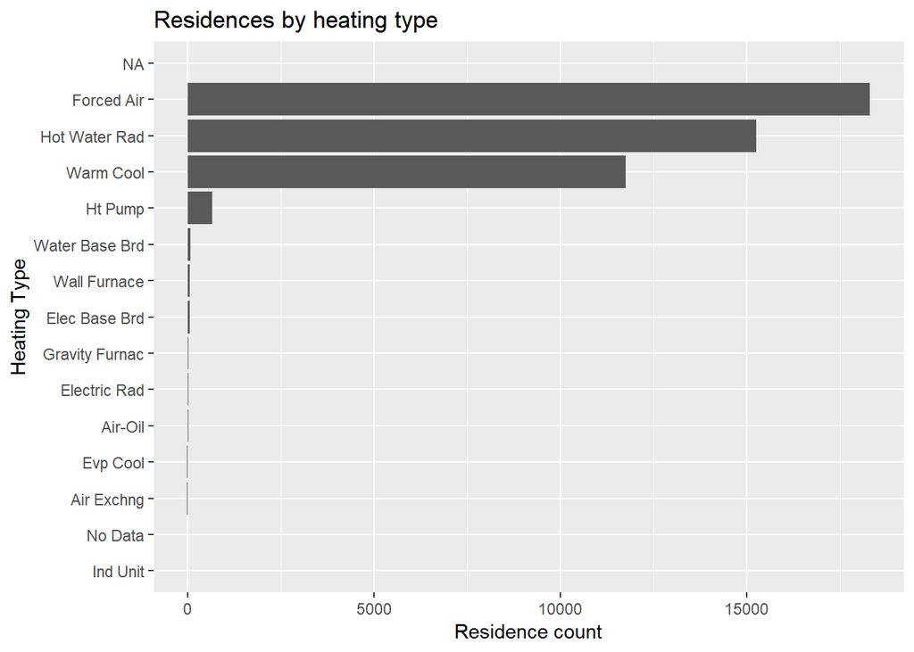

```r
#Let's draw bar graph
draw_bar_graph(HEAT_D, 'Residences by heating type','Heating Type')
```

‘Forced Air(1)’, ‘Hot Water Rad (13)’, Warm Cool(7)’ have majority of residences. Analyse rest of categories and any apparent relation with PRICE.

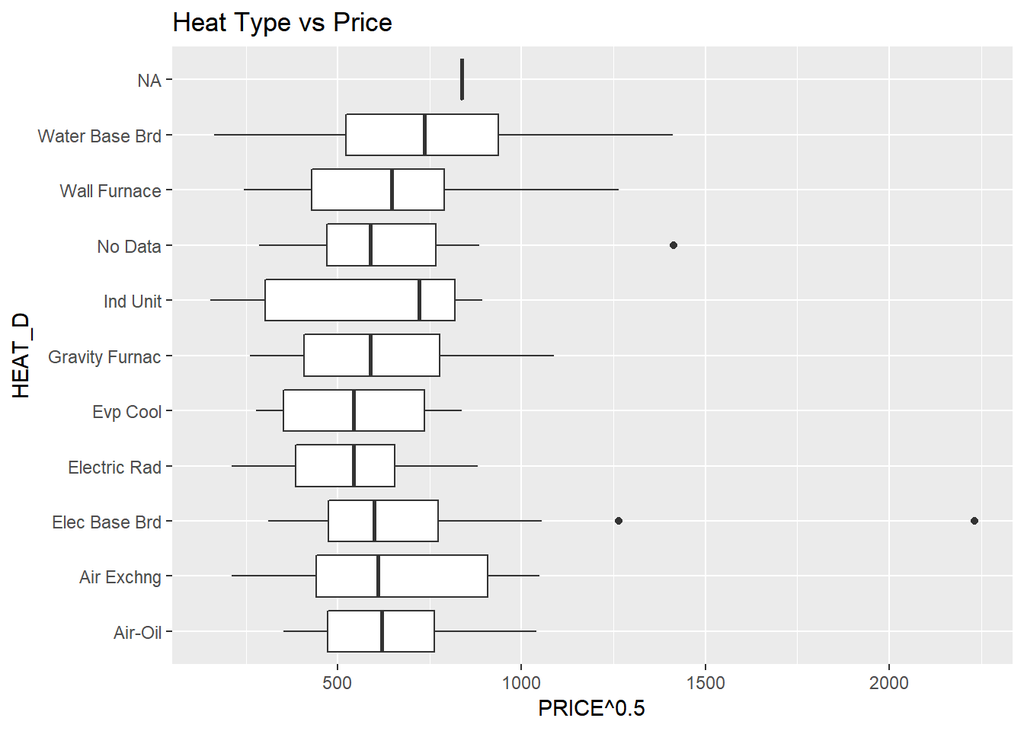

```r
condition <- c(1,7,8,13)
draw_boxplot_graph(HEAT, 'HEAT_D','Heat Type vs Price',condition)
```

Except one outlier all other have very similar distribution. Let’s look at No Data and NA values.

```r
residential_clean_df %>%
  filter(is.na(HEAT_D))
```

```
## # A tibble: 1 x 37
##   OBJECTID BATHRM HF_BATHRM  HEAT HEAT_D AC    NUM_UNITS ROOMS BEDRM   AYB
##      <int>  <int>     <int> <int> <chr>  <chr>     <int> <int> <int> <int>
## 1    17027     NA        NA    NA <NA>   <NA>         NA    NA    NA  2002
## # ... with 27 more variables: YR_RMDL <int>, EYB <int>, STORIES <dbl>,
## #   SALEDATE <dttm>, PRICE <int>, QUALIFIED <chr>, SALE_NUM <int>,
## #   GBA <int>, BLDG_NUM <int>, STYLE <int>, STYLE_D <chr>, STRUCT <int>,
## #   STRUCT_D <chr>, GRADE <int>, GRADE_D <chr>, CNDTN <int>,
## #   CNDTN_D <chr>, EXTWALL <int>, EXTWALL_D <chr>, ROOF <int>,
## #   ROOF_D <chr>, INTWALL <int>, INTWALL_D <chr>, KITCHENS <int>,
## #   FIREPLACES <int>, USECODE <int>, LANDAREA <int>
```

```r
# most of the columns on these 1 are NA. Let's drop these rows.
residential_clean_df <- residential_clean_df %>%
  filter(!is.na(HEAT_D))
```

Below will be the coding.  
heat_coding = hot_water_rad if ‘Hot Water Rad (13)’  
= forced_air if ‘Forced Air(1)’  
= warm_cool if Warm Cool(7)’  
= other_heating for all other.  
Make the column factor and remove HEAT and HEAT_D.

```r
residential_clean_df <- residential_clean_df %>%
  mutate(heat_coding = case_when(HEAT == 13 ~ 'ht_hot_water_rad',
                                 HEAT == 1 ~ 'ht_forced_air',
                                 HEAT == 7 ~ 'ht_warm_cool',
                                 TRUE ~ 'ht_other')) %>%
  mutate(heat_coding = as.factor(heat_coding))
```

### 0.3.2 Roof feature.

```r
table(residential_clean_df$ROOF_D, residential_clean_df$ROOF)
```

```
##
##                      0     1     2     3     4     5     6     7     8
##   Built Up           0     0 13750     0     0     0     0     0     0
##   Clay Tile          0     0     0     0     0     0     0     0     0
##   Comp Shingle       0 12862     0     0     0     0     0     0     0
##   Composition Ro     0     0     0     0     0     0     0     0    58
##   Concrete           0     0     0     0     0     0     0     0     0
##   Concrete Tile      0     0     0     0     0     0     0     0     0
##   Metal- Cpr         0     0     0     0     0     0     0    19     0
##   Metal- Pre         0     0     0     0     0   108     0     0     0
##   Metal- Sms         0     0     0     0     0     0 13140     0     0
##   Neopren            0     0     0     0     0     0     0     0     0
##   Shake              0     0     0     0   308     0     0     0     0
##   Shingle            0     0     0   196     0     0     0     0     0
##   Slate              0     0     0     0     0     0     0     0     0
##   Typical           75     0     0     0     0     0     0     0     0
##   Water Proof        0     0     0     0     0     0     0     0     0
##   Wood- FS           0     0     0     0     0     0     0     0     0
##
##                      9    10    11    12    13    14    15
##   Built Up           0     0     0     0     0     0     0
##   Clay Tile          0   248     0     0     0     0     0
##   Comp Shingle       0     0     0     0     0     0     0
##   Composition Ro     0     0     0     0     0     0     0
##   Concrete           0     0     0     1     0     0     0
##   Concrete Tile      4     0     0     0     0     0     0
##   Metal- Cpr         0     0     0     0     0     0     0
##   Metal- Pre         0     0     0     0     0     0     0
##   Metal- Sms         0     0     0     0     0     0     0
##   Neopren            0     0     0     0   799     0     0
##   Shake              0     0     0     0     0     0     0
##   Shingle            0     0     0     0     0     0     0
##   Slate              0     0  4717     0     0     0     0
##   Typical            0     0     0     0     0     0     0
##   Water Proof        0     0     0     0     0     2     0
##   Wood- FS           0     0     0     0     0     0     3
```

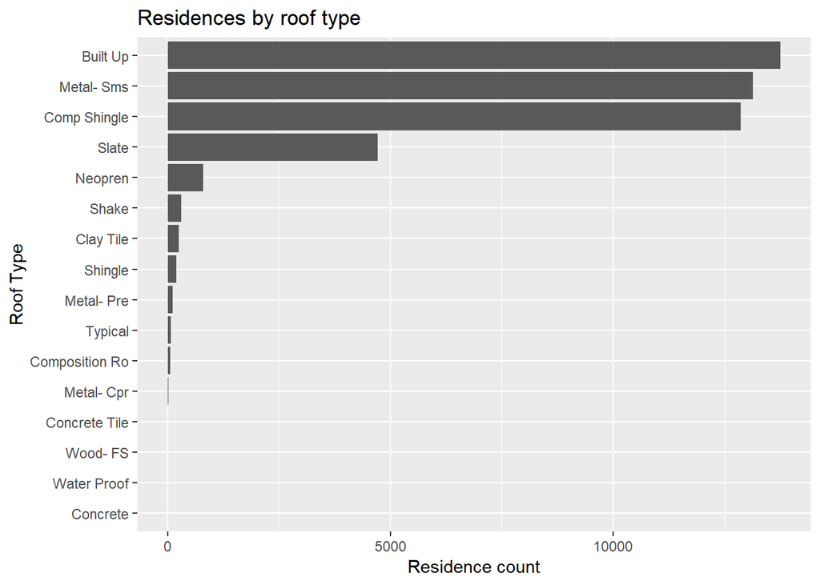

```r
#Let's draw bar graph
draw_bar_graph(ROOF_D, 'Residences by roof type','Roof Type')
```

Built Up(2), Comp Shingle(1), Metal - Sms(6) and Slate(11) are majority of houses roof types. Rest of the types can be bucketted together. Before that lets see if they have any relation with PRICE.

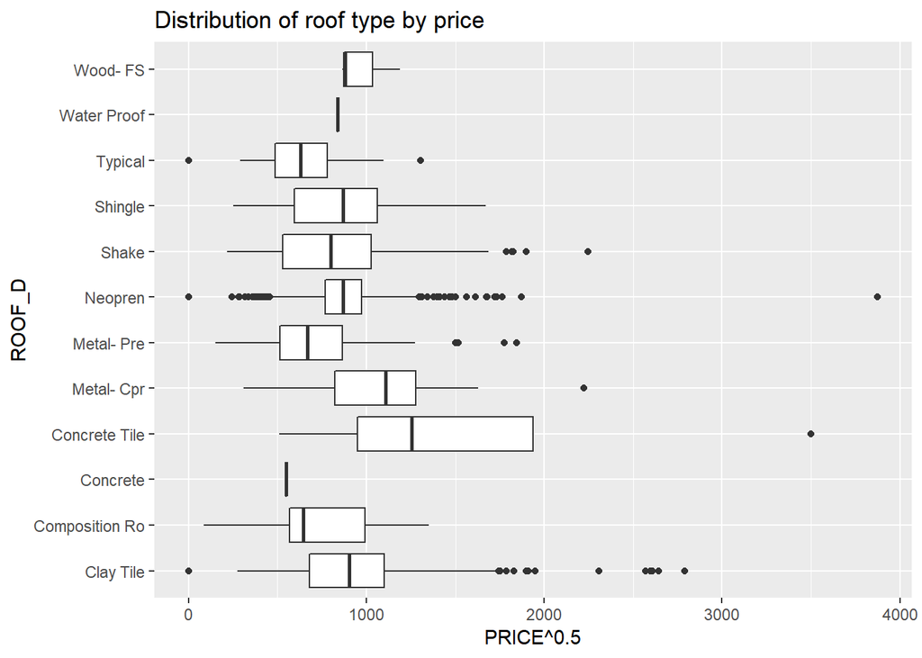

```r
condition <- c(1,2,6,11)
draw_boxplot_graph(ROOF, 'ROOF_D','Distribution of roof type by price',condition)
```

Concrete Tile and Metal-Cpr have higher median PRICE compared to other roof types.  
However they are very small number of residences. They are all bucketted in other.

```r
residential_clean_df <- residential_clean_df %>%
  mutate(roof_coding = case_when(ROOF == 1 ~ 'rf_comp_shingle',
                                 ROOF == 2 ~ 'rf_built_up',
                                 ROOF == 6 ~ 'rf_metal_sms',
                                 ROOF == 11 ~ 'rf_slate',
                                 TRUE ~ 'rf_other')) %>%
  mutate(roof_coding = as.factor(roof_coding))
```

### 0.3.3 Style feature.

```r
table(residential_clean_df$STYLE_D, residential_clean_df$STYLE)
```

```
##
##                       0     1     2     3     4     5     6     7     8
##   1 Story             0  1411     0     0     0     0     0     0     0
##   1.5 Story Fin       0     0     0   856     0     0     0     0     0
##   1.5 Story Unfin     0     0    42     0     0     0     0     0     0
##   2 Story             0     0     0     0 35203     0     0     0     0
##   2.5 Story Fin       0     0     0     0     0     0  3334     0     0
##   2.5 Story Unfin     0     0     0     0     0   306     0     0     0
##   3 Story             0     0     0     0     0     0     0  4626     0
##   3.5 Story Fin       0     0     0     0     0     0     0     0     0
##   3.5 Story Unfin     0     0     0     0     0     0     0     0     5
##   4 Story             0     0     0     0     0     0     0     0     0
##   4.5 Story Fin       0     0     0     0     0     0     0     0     0
##   4.5 Story Unfin     0     0     0     0     0     0     0     0     0
##   Bi-Level            0     0     0     0     0     0     0     0     0
##   Default            13     0     0     0     0     0     0     0     0
##   Split Foyer         0     0     0     0     0     0     0     0     0
##   Split Level         0     0     0     0     0     0     0     0     0
##   Vacant              0     0     0     0     0     0     0     0     0
##
##                       9    10    11    12    13    14    15    99
##   1 Story             0     0     0     0     0     0     0     0
##   1.5 Story Fin       0     0     0     0     0     0     0     0
##   1.5 Story Unfin     0     0     0     0     0     0     0     0
##   2 Story             0     0     0     0     0     0     0     0
##   2.5 Story Fin       0     0     0     0     0     0     0     0
##   2.5 Story Unfin     0     0     0     0     0     0     0     0
##   3 Story             0     0     0     0     0     0     0     0
##   3.5 Story Fin      71     0     0     0     0     0     0     0
##   3.5 Story Unfin     0     0     0     0     0     0     0     0
##   4 Story             0   188     0     0     0     0     0     0
##   4.5 Story Fin       0     0     0     1     0     0     0     0
##   4.5 Story Unfin     0     0     2     0     0     0     0     0
##   Bi-Level            0     0     0     0     8     0     0     0
##   Default             0     0     0     0     0     0     0     0
##   Split Foyer         0     0     0     0     0     0    89     0
##   Split Level         0     0     0     0     0   133     0     0
##   Vacant              0     0     0     0     0     0     0     2
```

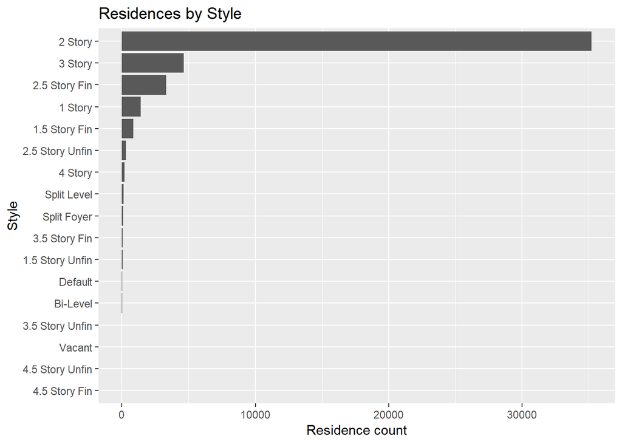

```r
#Let's draw bar graph
draw_bar_graph(STYLE_D, 'Residences by Style','Style')
```

2 story(4), 3 Story(7), 2.5 Story(6) and 1 Story(1) are majority. Rest will be analsyed for relationship with price to determine the possible grouping.

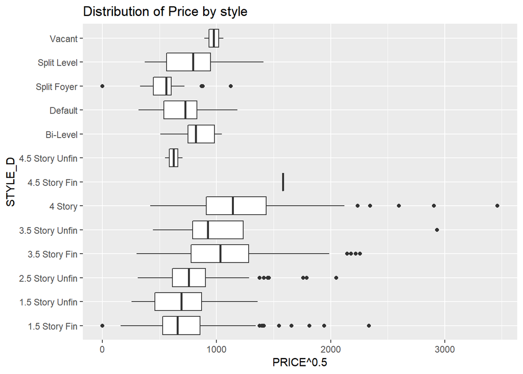

```r
exclusion_lst <- c(4,7,6,1)
draw_boxplot_graph(STYLE, 'STYLE_D','Distribution of Price by style',exclusion_lst)
```

4 story and 3.5 story finished are grouped and rest in other.

```r
residential_clean_df <- residential_clean_df %>%
  mutate(style_coding = case_when(STYLE == 4 ~ 'stl_2_story',
                                 STYLE == 7 ~ 'stl_3_story',
                                 STYLE == 6 ~ 'stl_2_h_story',
                                 STYLE == 1 ~ 'stl_1_story',
                                 STYLE %in% c(10,9) ~ 'stl_other_high',
                                 TRUE ~ 'stl_other')) %>%
  mutate(style_coding = as.factor(style_coding))
```

### 0.3.4 Structure feature.

```r
table(residential_clean_df$STRUCT_D, residential_clean_df$STRUCT)
```

```
##
##                     0     1     2     4     5     6     7     8    12
##   Condo             0     0     0     0     0     0     0     0     1
##   Default           3     0     0     0     0     0     0     0     0
##   Multi             0     0  1762     0     0     0     0     0     0
##   Row End           0     0     0     0     0  5580     0     0     0
##   Row Inside        0     0     0     0     0     0 19197     0     0
##   Semi-Detached     0     0     0     0     0     0     0  6556     0
##   Single            0 12974     0     0     0     0     0     0     0
##   Town End          0     0     0    63     0     0     0     0     0
##   Town Inside       0     0     0     0   154     0     0     0     0
```

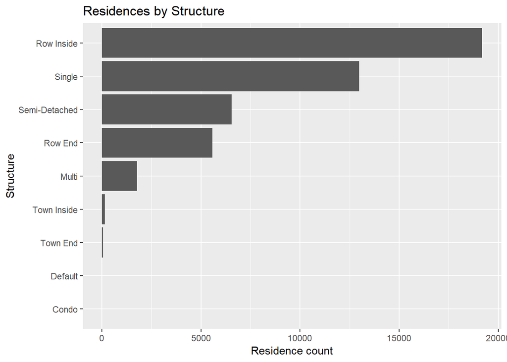

```r
#Let's draw bar graph
draw_bar_graph(STRUCT_D, 'Residences by Structure','Structure')
```

Row Inside(7), Single(1), Semi-detatched(8), Row_end(6) and multi(2) are clear groups. Let’s analyse others.

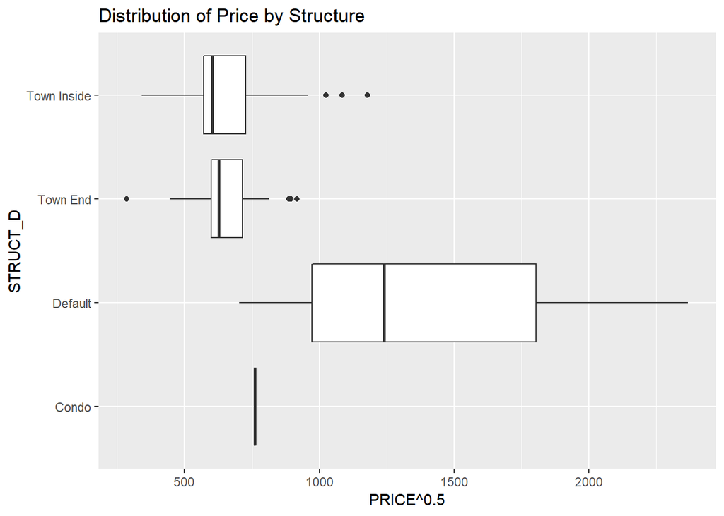

```r
exclusion_lst <- c(7,1,8,6,2)
draw_boxplot_graph(STRUCT, 'STRUCT_D','Distribution of Price by Structure',exclusion_lst)
```

Default structure has high price however there are only 3 residences. Let’s group everything else into bucket.

```r
residential_clean_df <- residential_clean_df %>%
  mutate(structure_coding = case_when(STRUCT == 7 ~ 'str_row_inside',
                                 STRUCT == 1 ~ 'str_single',
                                 STRUCT == 8 ~ 'str_semi_detached',
                                 STRUCT == 6 ~ 'str_row_end',
                                 STRUCT == 2 ~ 'str_multi',
                                 TRUE ~ 'stl_other')) %>%
  mutate(structure_coding = as.factor(structure_coding))
```

### 0.3.5 Grade feature.

```r
table(residential_clean_df$GRADE_D, residential_clean_df$GRADE)
```

```
##
##                     0     1     2     3     4     5     6     7     8
##   Above Average     0     0     0     0 13785     0     0     0     0
##   Average           0     0     0 14619     0     0     0     0     0
##   Excellent         0     0     0     0     0     0     0  1594     0
##   Exceptional-A     0     0     0     0     0     0     0     0     0
##   Exceptional-B     0     0     0     0     0     0     0     0     0
##   Exceptional-C     0     0     0     0     0     0     0     0     0
##   Exceptional-D     0     0     0     0     0     0     0     0     0
##   Fair Quality      0     0    42     0     0     0     0     0     0
##   Good Quality      0     0     0     0     0  9926     0     0     0
##   Low Quality       0     2     0     0     0     0     0     0     0
##   No Data           1     0     0     0     0     0     0     0     0
##   Superior          0     0     0     0     0     0     0     0  1325
##   Very Good         0     0     0     0     0     0  4399     0     0
##
##                     9    10    11    12
##   Above Average     0     0     0     0
##   Average           0     0     0     0
##   Excellent         0     0     0     0
##   Exceptional-A   395     0     0     0
##   Exceptional-B     0   145     0     0
##   Exceptional-C     0     0    33     0
##   Exceptional-D     0     0     0    24
##   Fair Quality      0     0     0     0
##   Good Quality      0     0     0     0
##   Low Quality       0     0     0     0
##   No Data           0     0     0     0
##   Superior          0     0     0     0
##   Very Good         0     0     0     0
```

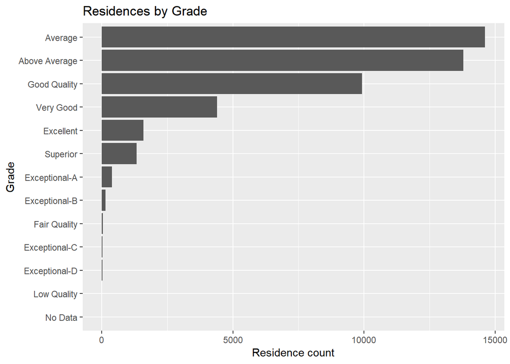

```r
#Let's draw bar graph
draw_bar_graph(GRADE_D, 'Residences by Grade','Grade')
```

Average(3), Above average(4), very good(6) and excellent(7) are buckets. Rest are analysed.

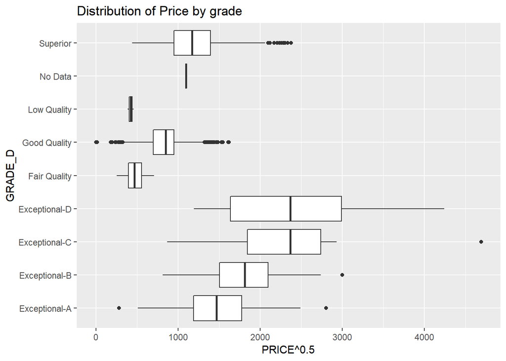

```r
exclusion_lst <- c(3,4,6,7)
draw_boxplot_graph(GRADE, 'GRADE_D','Distribution of Price by grade',exclusion_lst)
```

```r
residential_clean_df <- residential_clean_df %>%
  mutate(grade_coding = case_when(GRADE == 3 ~ 'grade_average',
                                 GRADE == 4 ~ 'grade_above_average',
                                 GRADE == 6 ~ 'grade_very_good',
                                 GRADE == 7 ~ 'grade_excellent',
                                 TRUE ~ 'grade_other')) %>%
  mutate(grade_coding = as.factor(grade_coding))
```

### 0.3.6 Condition feature.

```r
table(residential_clean_df$CNDTN_D, residential_clean_df$CNDTN)
```

```
##
##                 0     1     2     3     4     5     6
##   Average       0     0     0 16965     0     0     0
##   Default       1     0     0     0     0     0     0
##   Excellent     0     0     0     0     0     0   782
##   Fair          0     0   234     0     0     0     0
##   Good          0     0     0     0 22111     0     0
##   Poor          0    33     0     0     0     0     0
##   Very Good     0     0     0     0     0  6164     0
```

Condition seems to be ordered factor. let’s keep CNDTN as coding.

```r
residential_clean_df <- residential_clean_df %>%
  mutate(condition_coding = as.numeric(CNDTN))
```

### 0.3.7 Interanl Wall feature.

```r
table(residential_clean_df$INTWALL_D, residential_clean_df$INTWALL)
```

```
##
##                     0     1     2     3     4     5     6     7     8
##   Carpet            0     0  1424     0     0     0     0     0     0
##   Ceramic Tile      0     0     0     0    36     0     0     0     0
##   Default          33     0     0     0     0     0     0     0     0
##   Hardwood          0     0     0     0     0     0 35692     0     0
##   Hardwood/Carp     0     0     0     0     0     0     0     0     0
##   Lt Concrete       0     0     0     0     0     0     0     0     0
##   Parquet           0     0     0     0     0     0     0     9     0
##   Resiliant         0     6     0     0     0     0     0     0     0
##   Terrazo           0     0     0     0     0     3     0     0     0
##   Vinyl Comp        0     0     0     0     0     0     0     0     8
##   Vinyl Sheet       0     0     0     0     0     0     0     0     0
##   Wood Floor        0     0     0  2963     0     0     0     0     0
##
##                     9    10    11
##   Carpet            0     0     0
##   Ceramic Tile      0     0     0
##   Default           0     0     0
##   Hardwood          0     0     0
##   Hardwood/Carp     0     0  6074
##   Lt Concrete       0    37     0
##   Parquet           0     0     0
##   Resiliant         0     0     0
##   Terrazo           0     0     0
##   Vinyl Comp        0     0     0
##   Vinyl Sheet       5     0     0
##   Wood Floor        0     0     0
```

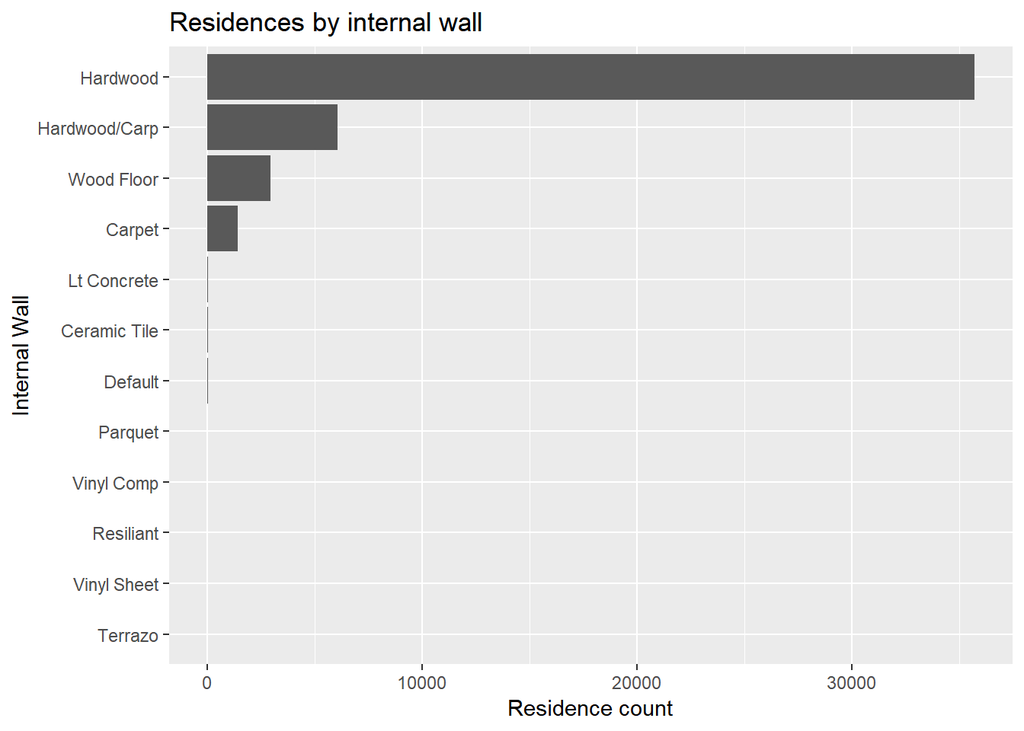

```r
#Let's draw bar graph
draw_bar_graph(INTWALL_D, 'Residences by internal wall','Internal Wall')
```

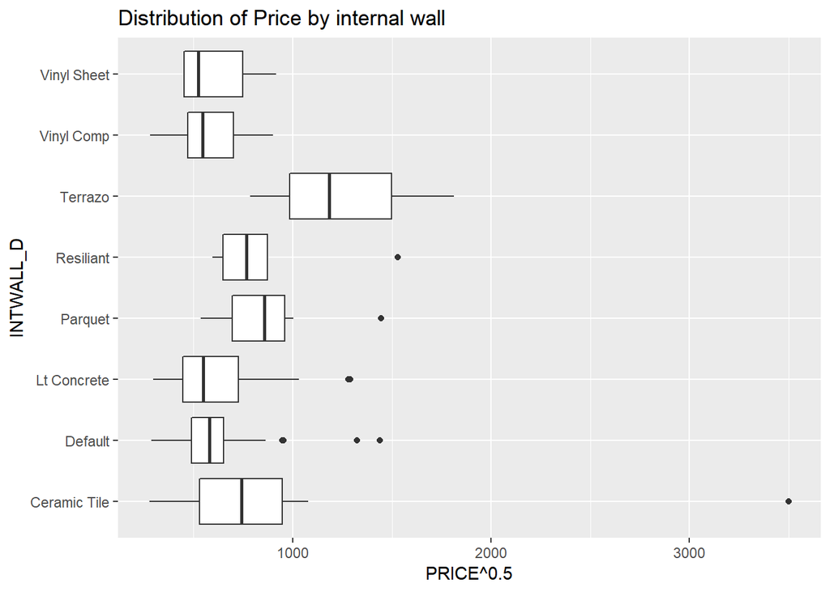

```r
exclusion_lst <- c(2,3,6,11)
draw_boxplot_graph(INTWALL, 'INTWALL_D','Distribution of Price by internal wall',exclusion_lst)
```

all these can be grouped into 1.

```r
residential_clean_df <- residential_clean_df %>%
  mutate(intwall_coding = case_when(EXTWALL == 2 ~ 'intwall_carpet',
                                 EXTWALL == 6 ~ 'intwall_hard_wood',
                                 TRUE ~ 'intwall_other')) %>%
  mutate(intwall_coding = as.factor(intwall_coding))
```

### 0.3.8 External Wall feature.

```r
table(residential_clean_df$EXTWALL_D, residential_clean_df$EXTWALL)
```

```
##
##                      0     1     2     3     4     5     6     7    10
##   Adobe              0     0     0     0     0     0     0     0     0
##   Aluminum           0     0     0     0     0     0     0     0     0
##   Brick Veneer       0     0     0     0     0     0     0     0   486
##   Brick/Siding       0     0     0     0     0     0     0     0     0
##   Brick/Stone        0     0     0     0     0     0     0     0     0
##   Brick/Stucco       0     0     0     0     0     0     0     0     0
##   Common Brick       0     0     0     0     0     0     0     0     0
##   Concrete           0     0     0     0     0     0     0     0     0
##   Concrete Block     0     0     0     0     0     0     0     0     0
##   Default            6     0     0     0     0     0     0     0     0
##   Face Brick         0     0     0     0     0     0     0     0     0
##   Hardboard          0     0    51     0     0     0     0     0     0
##   Metal Siding       0     0     0    20     0     0     0     0     0
##   Plywood            0     1     0     0     0     0     0     0     0
##   Shingle            0     0     0     0     0     0     0   383     0
##   Stone              0     0     0     0     0     0     0     0     0
##   Stone Veneer       0     0     0     0     0     0     0     0     0
##   Stone/Siding       0     0     0     0     0     0     0     0     0
##   Stone/Stucco       0     0     0     0     0     0     0     0     0
##   Stucco             0     0     0     0     0  1306     0     0     0
##   Stucco Block       0     0     0     0     0     0     0     0     0
##   Vinyl Siding       0     0     0     0  2354     0     0     0     0
##   Wood Siding        0     0     0     0     0     0  1784     0     0
##
##                     11    12    13    14    15    16    17    18    19
##   Adobe              0     0     0     0     0     2     0     0     0
##   Aluminum           0     0     0     0     0     0     0     0   326
##   Brick Veneer       0     0     0     0     0     0     0     0     0
##   Brick/Siding       0     0     0     0     0     0     0     0     0
##   Brick/Stone        0     0     0     0     0     0     0     0     0
##   Brick/Stucco       0     0     0     0     0     0     0     0     0
##   Common Brick       0     0     0 34776     0     0     0     0     0
##   Concrete           0     0     0     0     0     0     0    30     0
##   Concrete Block     0    28     0     0     0     0     0     0     0
##   Default            0     0     0     0     0     0     0     0     0
##   Face Brick         0     0     0     0   376     0     0     0     0
##   Hardboard          0     0     0     0     0     0     0     0     0
##   Metal Siding       0     0     0     0     0     0     0     0     0
```

[output cut: 20 more lines]

```
##   Concrete Block     0     0     0     0     0
##   Default            0     0     0     0     0
##   Face Brick         0     0     0     0     0
##   Hardboard          0     0     0     0     0
##   Metal Siding       0     0     0     0     0
##   Plywood            0     0     0     0     0
##   Shingle            0     0     0     0     0
##   Stone              0     0     0     0     0
##   Stone Veneer       0     0     0     0     0
##   Stone/Siding       0     0     0     0   176
##   Stone/Stucco       0     0     0   130     0
##   Stucco             0     0     0     0     0
##   Stucco Block       0     0     0     0     0
##   Vinyl Siding       0     0     0     0     0
##   Wood Siding        0     0     0     0     0
```

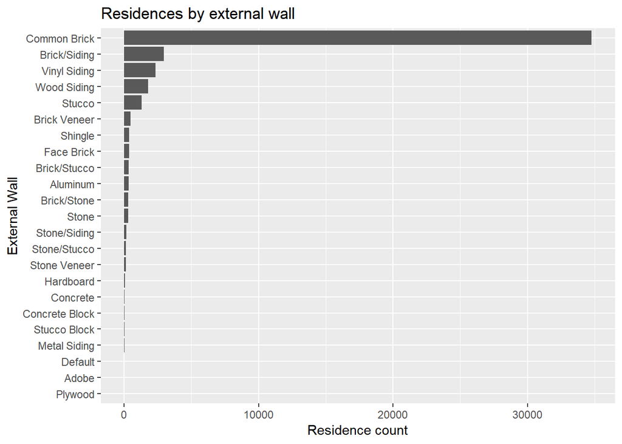

```r
#Let's draw bar graph
draw_bar_graph(EXTWALL_D, 'Residences by external wall','External Wall')
```

common brick(14), Brick/siding(22), vinyl siding(4) and wood siding(6) are buckets. Rest are analysed.

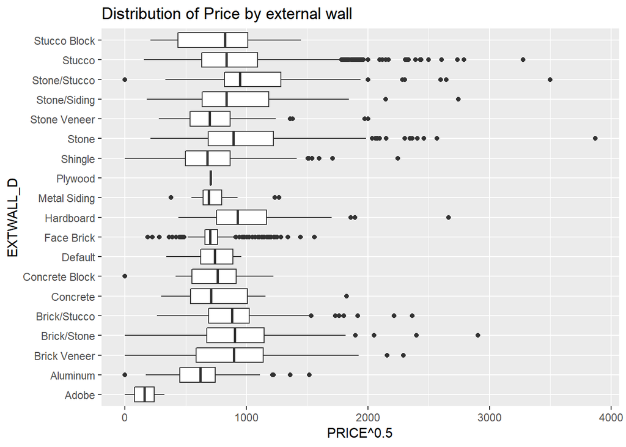

```r
exclusion_lst <- c(4,6,14,22)
draw_boxplot_graph(EXTWALL, 'EXTWALL_D','Distribution of Price by external wall',exclusion_lst)
```

all these can be grouped into 1.

```r
residential_clean_df <- residential_clean_df %>%
  mutate(etxwall_coding = case_when(EXTWALL == 4 ~ 'extwall_vinyl_siding',
                                 EXTWALL == 6 ~ 'extwall_siding',
                                 EXTWALL == 14 ~ 'extwall_common_brick',
                                 EXTWALL == 22 ~ 'extwall_brick_siding',
                                 TRUE ~ 'extwall_other')) %>%
  mutate(etxwall_coding = as.factor(etxwall_coding))
```

### 0.3.9 Air condition.

AC column has N, Y and 0 values. o is absence of AC which can be coded back to ‘N’.  
Residences with AC should be more valuable compared to residences with no AC. So N is coded to numeric 0 and Y to 1.

```r
residential_clean_df <- residential_clean_df %>%
  mutate(AC = if_else(AC == '0', 'N',AC))
# code N to 0 and Y to 1.
 residential_clean_df <- residential_clean_df %>%
  mutate(ac_coding = as.numeric(if_else(AC == 'N', '0','1')))
```

### 0.3.10 USE CODE.

Usecode. There are land use codes for each specific category. For our purpose we can group 11 to 19 to vacant and rest to non vacant.

```r
# 0 is vacant and 1 is non vacant
residential_clean_df <- residential_clean_df %>%
  mutate(LAND_USE = case_when(USECODE <= 19 ~ 0,
                              USECODE > 19 ~ 1)) %>%
  mutate(LAND_USE = as.factor(LAND_USE)) %>%
  select(-USECODE)
```

### 0.3.11 Features not needed.

1. Building Number - Building number. As per the meta data For parcels where multiple buildings exist, the primary building (such as the main residence) is assigned BLDG_NUM = 1. The other buildings or structures have BLDG_NUM values in random sequential order. So BLDG_NUM is just a number of building on a parcel which does not have any significance for the analysis. Removing the column.
2. Bathrooms - As above.
3. Air condition - As above.
4. Features and thier descriptions - As above.  
   They are EXTWALL, INTWALL, GRADE, CNDTN, HEAT, STYLE, STRUCT, ROOF

```r
residential_clean_df <- residential_clean_df %>%
  select(-BLDG_NUM, -AC, -EXTWALL, -EXTWALL_D, -INTWALL, -INTWALL_D, -GRADE, -GRADE_D, -CNDTN, -CNDTN_D, -HEAT, -HEAT_D, -STYLE, -STYLE_D, -STRUCT, -STRUCT_D, -ROOF, -ROOF_D)
```

## 0.4 Feature Engineering.

### 0.4.1 Bathrooms.

HF_BATHRM can be merged with BATHRM to create BATHROOMS_TOT variable.

```r
residential_clean_df <- residential_clean_df %>%
  mutate(BATHROOM_TOTAL = BATHRM + 0.5*HF_BATHRM)
summary(residential_clean_df$BATHROOM_TOTAL)
```

```
##    Min. 1st Qu.  Median    Mean 3rd Qu.    Max.    NA's
##   0.000   2.000   2.500   2.589   3.500  13.500       1
```

Check out the single record which have NA for BATHROOM_TOT

```r
residential_clean_df %>%
  filter(is.na(BATHROOM_TOTAL))
```

```
## # A tibble: 1 x 29
##   OBJECTID BATHRM HF_BATHRM NUM_UNITS ROOMS BEDRM   AYB YR_RMDL   EYB
##      <int>  <int>     <int>     <int> <int> <int> <int>   <int> <int>
## 1    11154      5        NA         5    12     5  1900      NA  1960
## # ... with 20 more variables: STORIES <dbl>, SALEDATE <dttm>, PRICE <int>,
## #   QUALIFIED <chr>, SALE_NUM <int>, GBA <int>, KITCHENS <int>,
## #   FIREPLACES <int>, LANDAREA <int>, heat_coding <fct>,
## #   roof_coding <fct>, style_coding <fct>, structure_coding <fct>,
## #   grade_coding <fct>, condition_coding <dbl>, intwall_coding <fct>,
## #   etxwall_coding <fct>, ac_coding <dbl>, LAND_USE <fct>,
## #   BATHROOM_TOTAL <dbl>
```

Only record with OBJECTID ‘11154’ has bathroom 5 and hf_bathroom as na. Total bath room can be imputed to 5.

```r
residential_clean_df[residential_clean_df['OBJECTID'] == 11154,'BATHROOM_TOTAL'] = 5
residential_clean_df <- residential_clean_df %>%
  filter(!is.na(BATHROOM_TOTAL))
```

Removing the bathrooms columns.

```r
residential_clean_df <- residential_clean_df %>%
  select(-BATHRM, -HF_BATHRM)
```

### 0.4.2 Analyse data for different room types.

They are ‘ROOMS’, ‘BEDRM’, ‘KITCHENS’, ‘FIREPLACES’, ‘BATHROOM_TOTAL’

```r
residential_clean_df %>%
  select('ROOMS','BEDRM','KITCHENS','FIREPLACES','BATHROOM_TOTAL') %>%
  summary()
```

```
##      ROOMS             BEDRM           KITCHENS       FIREPLACES
##  Min.   :  0.000   Min.   : 0.000   Min.   :0.000   Min.   : 0.0000
##  1st Qu.:  6.000   1st Qu.: 3.000   1st Qu.:1.000   1st Qu.: 0.0000
##  Median :  7.000   Median : 3.000   Median :1.000   Median : 0.0000
##  Mean   :  7.413   Mean   : 3.435   Mean   :1.229   Mean   : 0.6812
##  3rd Qu.:  8.000   3rd Qu.: 4.000   3rd Qu.:1.000   3rd Qu.: 1.0000
##  Max.   :101.000   Max.   :53.000   Max.   :6.000   Max.   :13.0000
##  NA's   :9         NA's   :2        NA's   :1       NA's   :1
##  BATHROOM_TOTAL
##  Min.   : 0.000
##  1st Qu.: 2.000
##  Median : 2.500
##  Mean   : 2.589
##  3rd Qu.: 3.500
##  Max.   :13.500
##
```

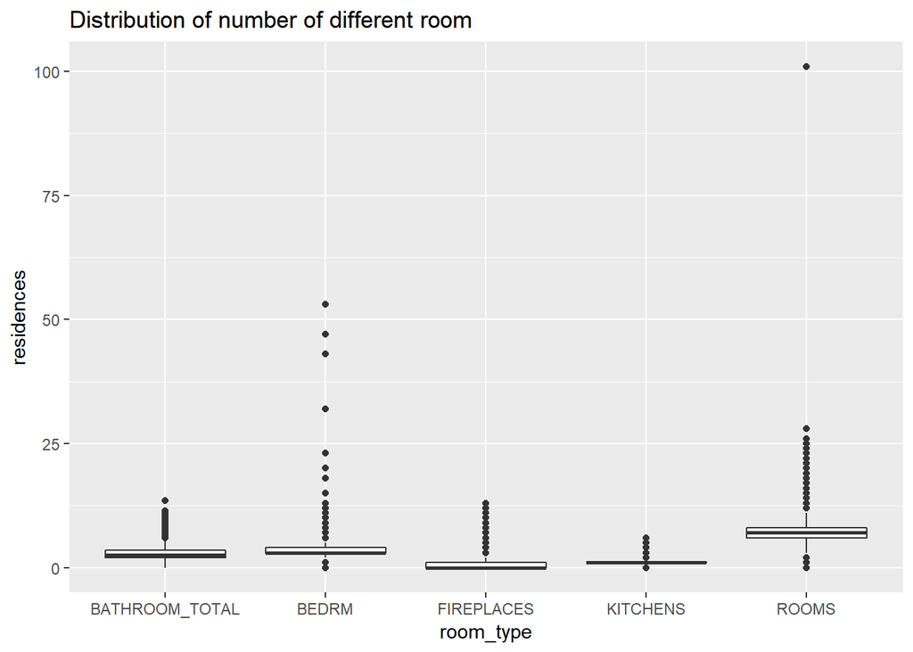

```r
# Let's draw boxplots to check the data distributions.
residential_clean_df %>%
  select('ROOMS','BEDRM','KITCHENS','FIREPLACES','BATHROOM_TOTAL') %>%
  gather(key = 'room_type', value = 'room_count') %>%
  ggplot(data = ., aes(x=room_type, y = room_count )) +
  geom_boxplot() +
  labs(title = 'Distribution of number of different room', y = 'residences')
```

residence with 101 ROOMS is outlier. Let’s investigate it.

```r
residential_clean_df[residential_clean_df['ROOMS'] == 101,]
```

```
## # A tibble: 10 x 27
##    OBJECTID NUM_UNITS ROOMS BEDRM   AYB YR_RMDL   EYB STORIES
##       <int>     <int> <int> <int> <int>   <int> <int>   <dbl>
##  1       NA        NA    NA    NA    NA      NA    NA      NA
##  2       NA        NA    NA    NA    NA      NA    NA      NA
##  3       NA        NA    NA    NA    NA      NA    NA      NA
##  4       NA        NA    NA    NA    NA      NA    NA      NA
##  5       NA        NA    NA    NA    NA      NA    NA      NA
##  6       NA        NA    NA    NA    NA      NA    NA      NA
##  7    63895         1   101     3  1936    2006  1982       2
##  8       NA        NA    NA    NA    NA      NA    NA      NA
##  9       NA        NA    NA    NA    NA      NA    NA      NA
## 10       NA        NA    NA    NA    NA      NA    NA      NA
## # ... with 19 more variables: SALEDATE <dttm>, PRICE <int>,
## #   QUALIFIED <chr>, SALE_NUM <int>, GBA <int>, KITCHENS <int>,
## #   FIREPLACES <int>, LANDAREA <int>, heat_coding <fct>,
## #   roof_coding <fct>, style_coding <fct>, structure_coding <fct>,
## #   grade_coding <fct>, condition_coding <dbl>, intwall_coding <fct>,
## #   etxwall_coding <fct>, ac_coding <dbl>, LAND_USE <fct>,
## #   BATHROOM_TOTAL <dbl>
```

```r
# It seems to be fat fingure error. Rather ROOMS seems to be 10 looking at number of kitchens. bede room etc.

residential_clean_df[residential_clean_df$OBJECTID == 63895,]['ROOMS'] = 10

residential_clean_df[residential_clean_df$BEDRM > 20,]
```

```
## # A tibble: 7 x 27
##   OBJECTID NUM_UNITS ROOMS BEDRM   AYB YR_RMDL   EYB STORIES
##      <int>     <int> <dbl> <int> <int>   <int> <int>   <dbl>
## 1       NA        NA    NA    NA    NA      NA    NA    NA
## 2    23831         1    11    53  1940    1999  1972     2
## 3    23903         1     6    32  1940    1998  1969     2
## 4    44222         1     7    43  1915    2014  1969     2
## 5    44946         1     7    47  1947      NA  1963     2.5
## 6    62916         1     5    23  1925      NA  1954     1
## 7       NA        NA    NA    NA    NA      NA    NA    NA
## # ... with 19 more variables: SALEDATE <dttm>, PRICE <int>,
## #   QUALIFIED <chr>, SALE_NUM <int>, GBA <int>, KITCHENS <int>,
## #   FIREPLACES <int>, LANDAREA <int>, heat_coding <fct>,
## #   roof_coding <fct>, style_coding <fct>, structure_coding <fct>,
## #   grade_coding <fct>, condition_coding <dbl>, intwall_coding <fct>,
## #   etxwall_coding <fct>, ac_coding <dbl>, LAND_USE <fct>,
## #   BATHROOM_TOTAL <dbl>
```

### 0.4.3 Year variables.

AYB - Actual year built.  
EYB - Estimated year built.  
YR_RMDL - Year remodelled.  
SaleDate - Sale of the residential property. Rationale of feature engineering.  
1. Take into account the depreciation. Calculate AGe of residential property at the time of sale.  
2. Age can be calculated by sale_year - max(AYB, EYB, YR_RMDL)  
3. there should be differentiation of property remodelled vs newly buit in the same year. Create one variable (factor) if the property is remodelled.

```r
# Out of total 27,960 remodelled houses, 16,685 are remodelled before sale year. So these should be having flag for remodelled.

residential_clean_df %>%
  filter(! is.na(YR_RMDL)) %>%
  summarise(n())
```

```
## # A tibble: 1 x 1
##   `n()`
##   <int>
## 1 27960
```

```r
residential_clean_df %>%
  filter(YR_RMDL < year(SALEDATE)) %>%
  summarise(n())
```

```
## # A tibble: 1 x 1
##   `n()`
##   <int>
## 1 16685
```

```r
residential_clean_df <- residential_clean_df %>%
  mutate(remodelled = if_else(YR_RMDL < year(SALEDATE), 0 ,1)) %>%
  mutate(remodelled = if_else(is.na(remodelled),1,remodelled)) %>%
  mutate(remodelled = as.factor(remodelled))
```

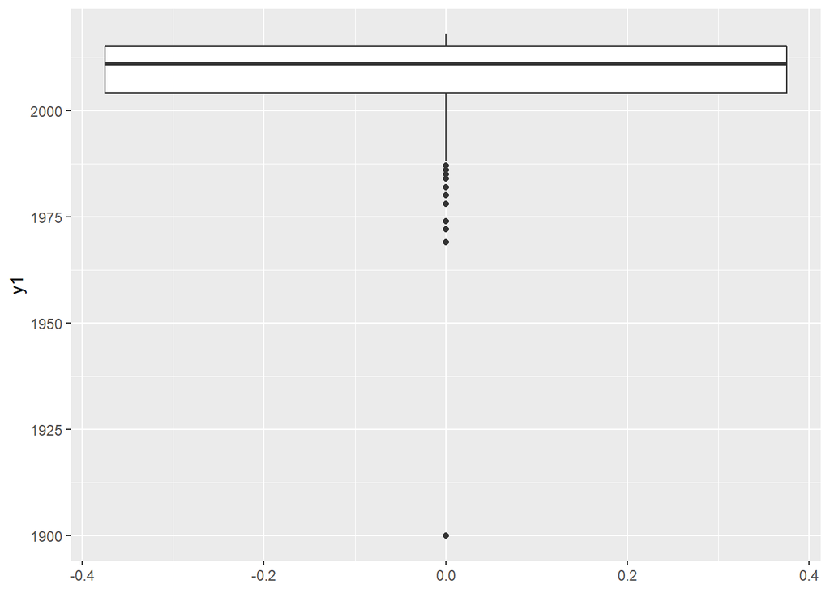

```r
residential_clean_df %>%
  select(SALEDATE) %>%
  mutate(y1 = year(SALEDATE)) %>%
ggplot(data =., aes(y = y1)) +
  geom_boxplot()
```

```r
# One record withSALEDATE 1900 has no price. Deleting it.
residential_clean_df <- residential_clean_df %>%
  filter(!year(SALEDATE) == 1900)

# there are 9 records with year_remodelled is less than actual year build and 15 records with estimated year built less than actual year build. These does not make sense. Removing these records.

year_rows_removal <- which(residential_clean_df$EYB < residential_clean_df$AYB)
year_rows_removal <- union(year_rows_removal,which(residential_clean_df$YR_RMDL < residential_clean_df$AYB))
residential_clean_df <- residential_clean_df[-year_rows_removal,]

residential_clean_df %>%
  select(AYB, EYB, YR_RMDL, SALEDATE, remodelled, PRICE)
```

```
## # A tibble: 46,265 x 6
##      AYB   EYB YR_RMDL SALEDATE            remodelled   PRICE
##    <int> <int>   <int> <dttm>              <fct>        <int>
##  1  1870  1978    2005 2015-12-16 00:00:00 0          1525000
##  2  1895  1986      NA 2015-07-02 00:00:00 1          1380000
##  3  1885  1960      NA 1994-05-23 00:00:00 1           269500
##  4  1875  1982    1963 2003-09-09 00:00:00 0           936500
##  5  1890  1969    2017 2017-06-16 00:00:00 1          2180000
##  6  1890  1960      NA 2015-04-09 00:00:00 1           980000
##  7  1890  1960    1989 2016-10-17 00:00:00 0          1200000
##  8  1890  1960      NA 2006-04-25 00:00:00 1           850000
##  9  1900  1963    2011 2005-07-07 00:00:00 1          1250000
## 10  1895  1977    1997 2013-05-31 00:00:00 0          1455000
## # ... with 46,255 more rows
```

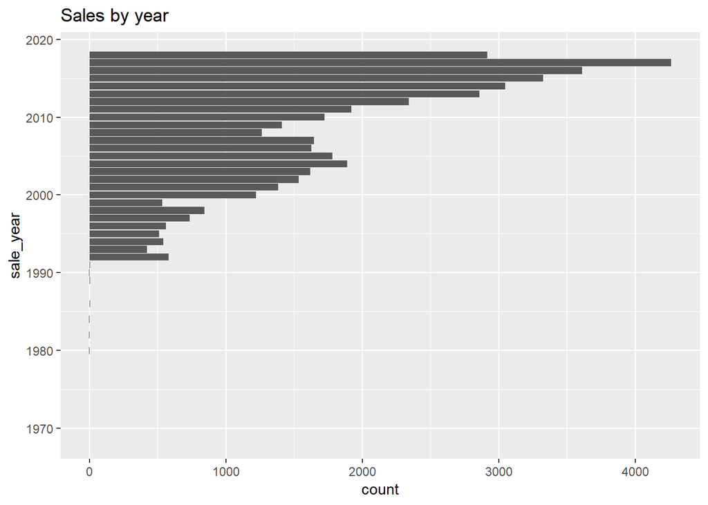

```r
# calculate age variable which is as of sale year.
residential_clean_df <- residential_clean_df %>%
  mutate(sale_year = year(SALEDATE)) %>%
  mutate(age = pmin(if_else(sale_year - AYB <0, 999,  sale_year - AYB ),
                    if_else(sale_year - EYB <0, 999,  sale_year - EYB ),
                    if_else(sale_year - YR_RMDL <0, 999,  sale_year - YR_RMDL ),
                    na.rm=TRUE))
# there are 145 records which has sale date earlier than AYB, EYB and YR_RMDL. These records are all removed.
residential_clean_df <- residential_clean_df[-which(residential_clean_df$age==999),]
# excluding the date columns
residential_clean_df <- residential_clean_df %>%
  select(-AYB, -EYB, -YR_RMDL, -SALEDATE)


ggplot(data = residential_clean_df, aes(x = sale_year))+
  geom_bar() +
  labs(title = 'Sales by year') +
  coord_flip()
```

```r
# There are very few (1 or 2) sales before 1992. Removing those.

residential_clean_df <- residential_clean_df %>%
  filter(sale_year >= 1992)

# sale year should be factor. 1 year increase in sale year does not necesserily mean 1 unit increase in sale pice.
residential_clean_df <- residential_clean_df%>%
  mutate(sale_year = as.factor(sale_year))
```

### 0.4.4 Analyse area

GBA and LandAREA.

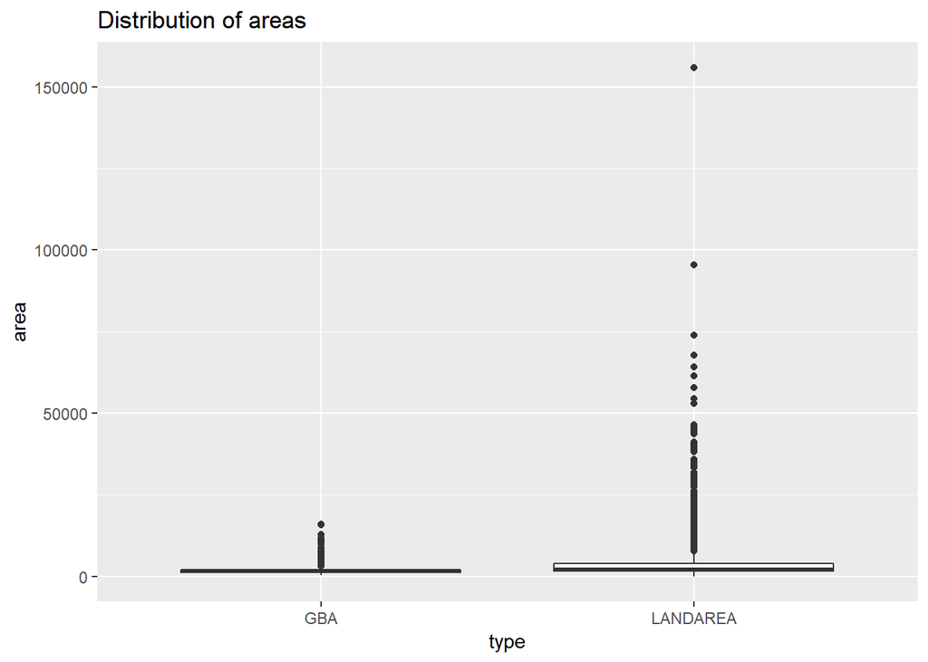

```r
residential_clean_df %>%
  select(GBA,LANDAREA) %>%
  gather(key = 'type', value = 'area') %>%
  ggplot(data = ., aes(x = type, y = area)) +
  geom_boxplot() +
  labs(title = 'Distribution of areas')
```

Lets bucket land area and GBA into 5 groups each based on quartiles.

```r
residential_clean_df <- residential_clean_df %>%
  mutate(GBA_Bucket = case_when(GBA <= quantile(GBA,probs=c(0.25)) ~ 0,
                                GBA <= median(GBA, na.rm = TRUE) ~1,
                                GBA <= quantile(GBA,probs=c(0.75)) ~ 2,
                                GBA <= quantile(GBA,probs=c(0.90)) ~ 3,
                                GBA > quantile(GBA,probs=c(0.90)) ~ 4)) %>%
  mutate(LANDAREA_Bucket = case_when(LANDAREA <= quantile(LANDAREA,probs=c(0.25)) ~ 0,
                                LANDAREA <= median(LANDAREA, na.rm = TRUE) ~1,
                                LANDAREA <= quantile(LANDAREA,probs=c(0.75)) ~ 2,
                                LANDAREA <= quantile(LANDAREA,probs=c(0.90)) ~ 3,
                                LANDAREA > quantile(LANDAREA,probs=c(0.90)) ~ 4))
# remove LAND_AREA and GBA
residential_clean_df <- residential_clean_df %>%
  select(-c(LANDAREA, GBA, SALE_NUM))
```

### 0.4.5 Missing Values.

```r
summary(residential_clean_df)
```

```
##     OBJECTID        NUM_UNITS         ROOMS            BEDRM
##  Min.   :     1   Min.   :0.000   Min.   : 0.000   Min.   : 0.000
##  1st Qu.: 23158   1st Qu.:1.000   1st Qu.: 6.000   1st Qu.: 3.000
##  Median : 48370   Median :1.000   Median : 7.000   Median : 3.000
##  Mean   : 50251   Mean   :1.195   Mean   : 7.406   Mean   : 3.433
##  3rd Qu.: 77171   3rd Qu.:1.000   3rd Qu.: 8.000   3rd Qu.: 4.000
##  Max.   :107231   Max.   :6.000   Max.   :28.000   Max.   :53.000
##                                   NA's   :9        NA's   :2
##     STORIES            PRICE           QUALIFIED            KITCHENS
##  Min.   :  0.000   Min.   :       0   Length:46092       Min.   :0.000
##  1st Qu.:  2.000   1st Qu.:  290000   Class :character   1st Qu.:1.000
##  Median :  2.000   Median :  508850   Mode  :character   Median :1.000
##  Mean   :  2.137   Mean   :  628634                      Mean   :1.229
##  3rd Qu.:  2.000   3rd Qu.:  800000                      3rd Qu.:1.000
##  Max.   :826.000   Max.   :22000000                      Max.   :6.000
##  NA's   :27                                              NA's   :1
##    FIREPLACES                heat_coding             roof_coding
##  Min.   : 0.0000   ht_forced_air   :18203   rf_built_up    :13715
##  1st Qu.: 0.0000   ht_hot_water_rad:15240   rf_comp_shingle:12762
##  Median : 0.0000   ht_other        :  974   rf_metal_sms   :13122
##  Mean   : 0.6814   ht_warm_cool    :11675   rf_other       : 1804
##  3rd Qu.: 1.0000                            rf_slate       : 4689
##  Max.   :13.0000
##  NA's   :1
##          style_coding            structure_coding
##  stl_1_story   : 1399   stl_other        :  219
##  stl_2_h_story : 3303   str_multi        : 1756
##  stl_2_story   :35096   str_row_end      : 5555
##  stl_3_story   : 4587   str_row_inside   :19147
##  stl_other     : 1452   str_semi_detached: 6532
##  stl_other_high:  255   str_single       :12883
##
##               grade_coding   condition_coding           intwall_coding
##  grade_above_average:13723   Min.   :0.000    intwall_carpet   :   50
##  grade_average      :14587   1st Qu.:3.000    intwall_hard_wood: 1776
##  grade_excellent    : 1583   Median :4.000    intwall_other    :44266
##  grade_other        :11812   Mean   :3.785
##  grade_very_good    : 4387   3rd Qu.:4.000
##                              Max.   :6.000
##
```

[output cut: 9 more lines]

```
##  0:16665    2017   : 4262   Min.   :  0.0   Min.   :0.000
##  1:29427    2016   : 3610   1st Qu.:  1.0   1st Qu.:0.000
##             2015   : 3324   Median : 12.0   Median :1.000
##             2014   : 3047   Mean   : 21.1   Mean   :1.598
##             2018   : 2916   3rd Qu.: 41.0   3rd Qu.:2.000
##             2013   : 2859   Max.   :103.0   Max.   :4.000
##             (Other):26074
##  LANDAREA_Bucket
##  Min.   :0.000
##  1st Qu.:0.000
##  Median :1.000
##  Mean   :1.595
##  3rd Qu.:2.000
##  Max.   :4.000
##
```

There are 38 rows with missing values excluding PRICE columns. Let’s drop them.

```r
residential_clean_df <- residential_clean_df %>%
  drop_na(-PRICE)

residential_clean_df <- residential_clean_df %>%
  filter(PRICE != 0)
```

### 0.4.6 dummyfication.

Convert all factor colmns to dummy variables.

```r
residential_clean_df <- residential_clean_df %>%
  select(-QUALIFIED)
factor_columns <- residential_clean_df %>%
  Filter(f = is.factor) %>%
  names
dv <- dummyVars('~.', data = residential_clean_df, fullRank = TRUE)
res_dummy_df <- data.frame(predict(dv, newdata = residential_clean_df))
```

### 0.4.7 correlations.

[figure not shown]

```r
rcorr_matrix <- res_dummy_df %>%
  select(-OBJECTID, -PRICE) %>%
  as.matrix() %>%
  rcorr()
corrplot(rcorr_matrix$r, type='upper', order = 'hclust',tl.cex = 0.8)
```

```r
high_corr_df <- as.data.frame(rcorr_matrix$r) %>%
  rownames_to_column(var = 'feat1') %>%
  gather(key = 'feat2', value = 'corr', -feat1) %>%
  filter(abs(corr) >= 0.7, feat1 != feat2)
p_value_df <- as.data.frame(rcorr_matrix$P) %>%
  rownames_to_column(var = 'feat1') %>%
  gather(key = 'feat2', value = 'p', -feat1) %>%
  filter(feat1 != feat2)

multi_colinearity <- high_corr_df %>%
  left_join(p_value_df) %>%
  arrange(feat1, feat2)
```

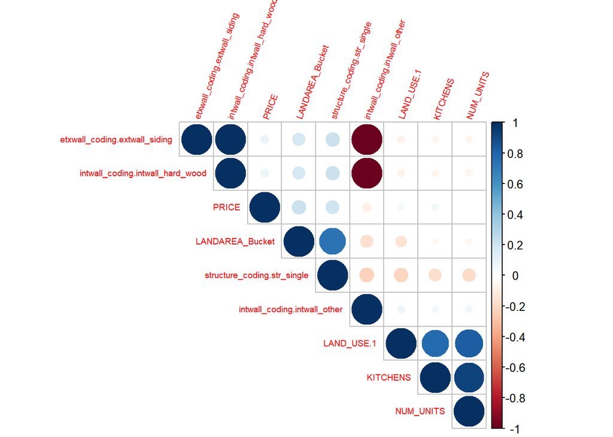

```r
multicol_feature <- unique(multi_colinearity$feat1)

rcorr_matrix_2 <- res_dummy_df %>%
  select(!!multicol_feature, PRICE) %>%
  as.matrix() %>%
  rcorr()
corrplot(rcorr_matrix_2$r, type='upper', order = 'hclust',tl.cex = 0.6,tl.srt = 70)
```

None of these 8 features indepently have high correlatio with independent variable PRICE. We will remove below features.  
1. etxwall_coding.extwall_siding 2. intwall_coding.intwall_other  
3. KITCHENS  
4. structure_coding.str_single

```r
res_dummy_df_uncorr <- res_dummy_df %>%  select(-etxwall_coding.extwall_siding,-intwall_coding.intwall_other, -KITCHENS,-structure_coding.str_single)
```

### 0.4.8 Zerovariance columns.

```r
nzv_cols <- res_dummy_df_uncorr %>%
  select(-PRICE) %>%
  nearZeroVar(names = TRUE, freqCut = 99/1)

#res_dummy_df_uncorr <- res_dummy_df_uncorr %>% select(-!!nzv_cols)
```

## 0.5 Test and train dataset.

### 0.5.1 Removing outliers.

```r
res_data_modelling <- res_dummy_df_uncorr %>%
  filter(!is.na(PRICE))
```

ROOMS.  
NUM_UNITS.  
BEDRM  
STORIES  
FIREPLACES  
BATH_ROOM_TOTAL  
AGE  
SALE_YEAR  
and  
PRICE.

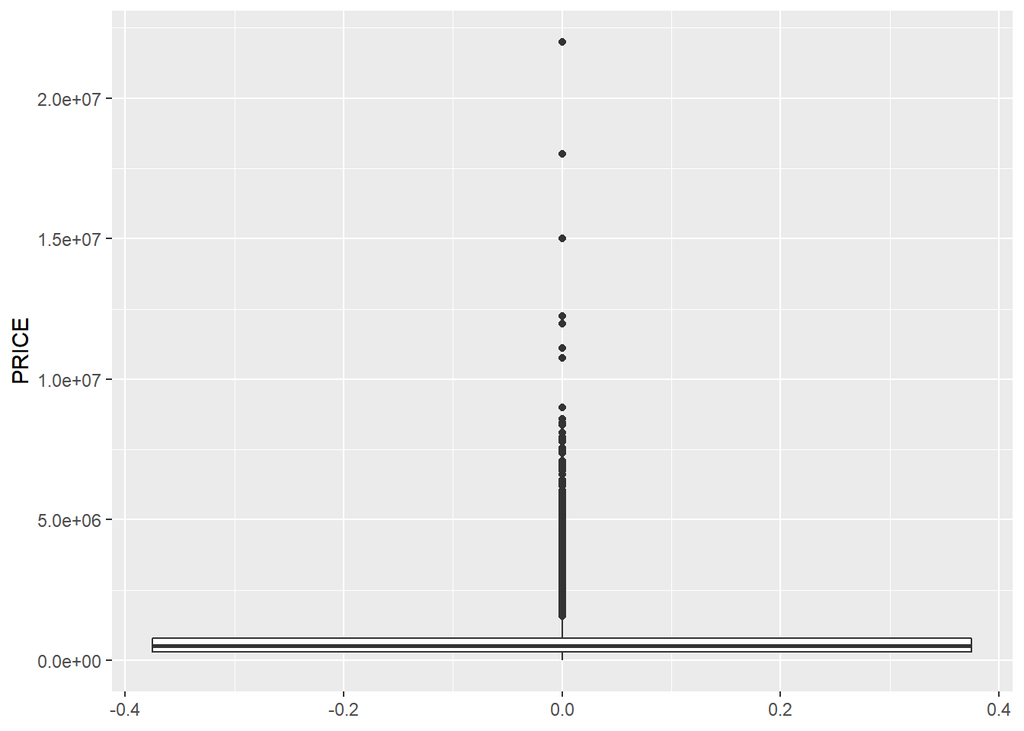

```r
res_data_modelling %>%
  select(PRICE) %>%
  ggplot(data = ., aes(y = PRICE)) +
  geom_boxplot()
```

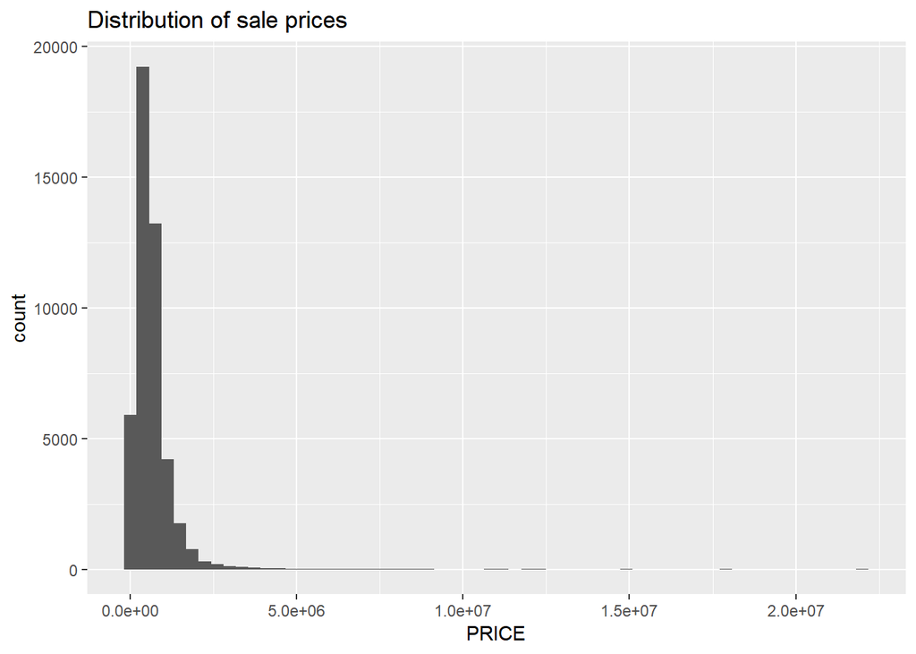

```r
res_data_modelling %>%
  select(PRICE) %>%
  ggplot(data = ., aes(x = PRICE)) +
  geom_histogram(bins=60) +
  labs(title = 'Distribution of sale prices')
```

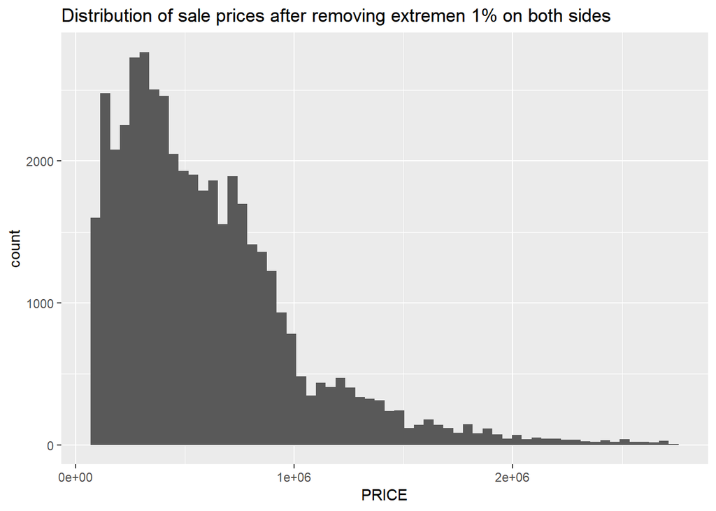

```r
res_data_modelling %>%
  filter(PRICE > quantile(PRICE,1/100),
         PRICE < quantile(PRICE,99/100)) %>%
  select(PRICE) %>%
  ggplot(data = ., aes(x = PRICE)) +
  geom_histogram(bins=60)  +
  labs(title = 'Distribution of sale prices after removing extremen 1% on both sides')
```

```r
PRICE_outlier_rows <- which(res_data_modelling$PRICE < quantile(res_data_modelling$PRICE,1/100)|
        res_data_modelling$PRICE > quantile(res_data_modelling$PRICE,99/100))

set.seed(12309)
# Take log of PRICE for prediction as PRICE need to be positive.
res_data_modelling <- res_data_modelling%>%
  mutate(PRICE_LOG = log(PRICE))
```

PRICE is dependent variable and only positive value makes sense. Hence it needs to be log transfomred. Looking at the above 3 graphs top and bottom 1 percentile can be removed as outliers.

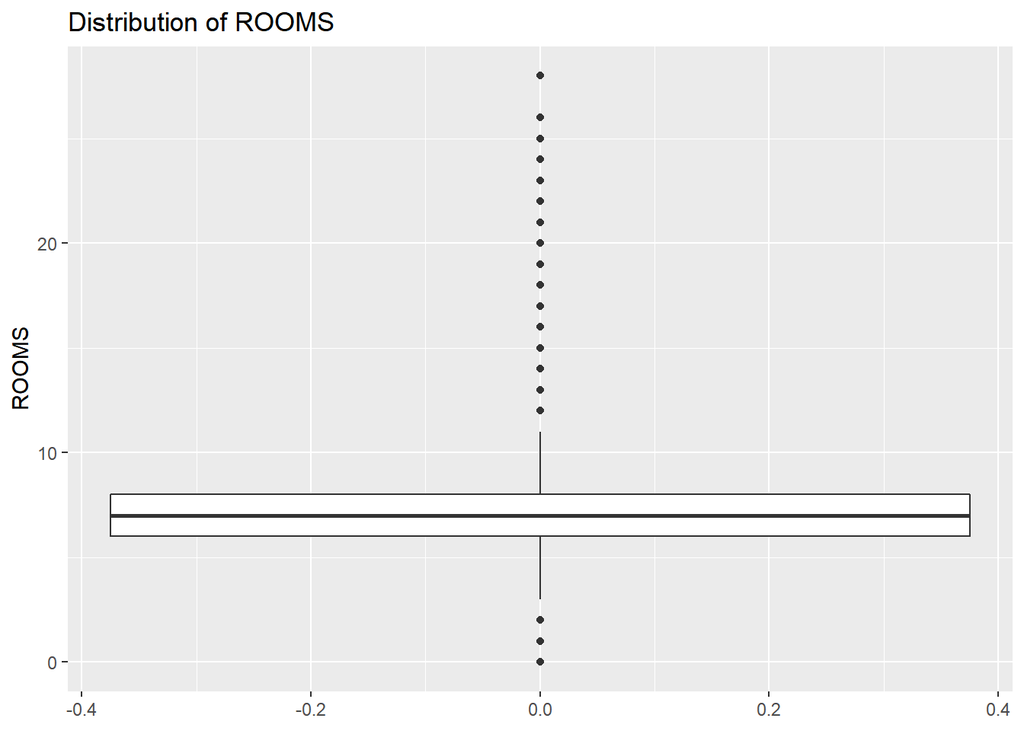

```r
res_data_modelling %>%
  select(ROOMS) %>%
  ggplot(data = ., aes(y = ROOMS)) +
  geom_boxplot() +
  labs(title = 'Distribution of ROOMS')
```

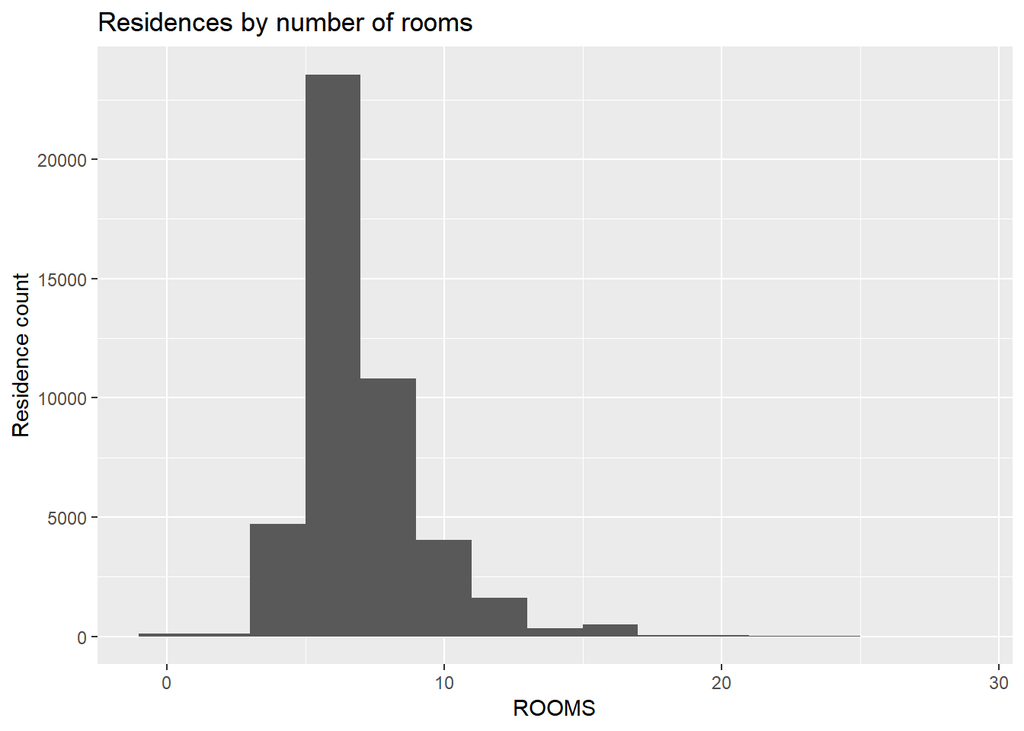

```r
res_data_modelling %>%
  select(ROOMS) %>%
  ggplot(data = ., aes(x = ROOMS)) +
  geom_histogram(bins=15)+
  labs(title = 'Residences by number of rooms', y = 'Residence count')
```

```r
ROOMS_outlier_rows <- which(res_data_modelling$ROOMS == 0 |
        res_data_modelling$ROOMS >12 )
```

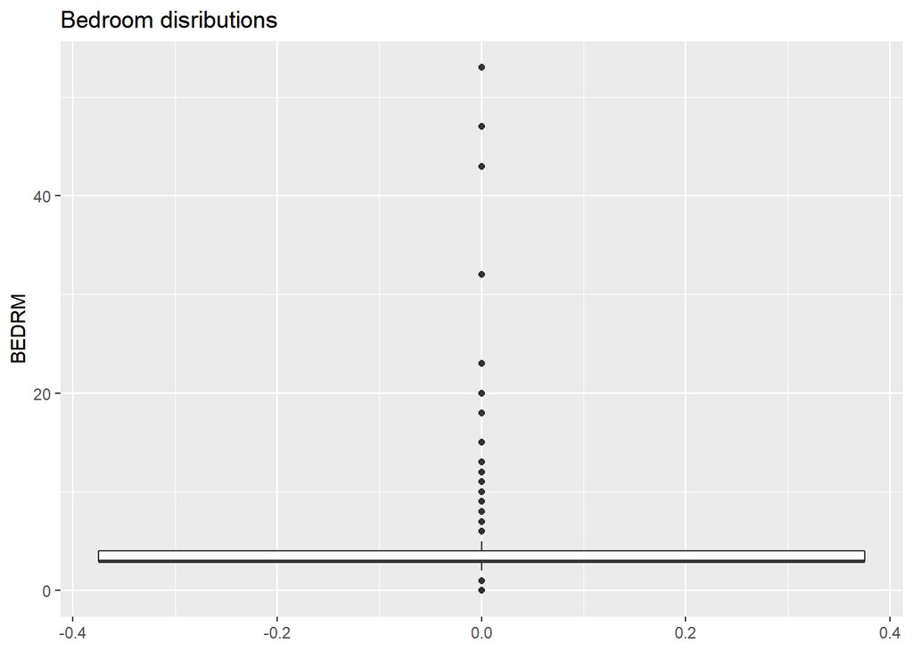

```r
res_data_modelling %>%
  select(BEDRM) %>%
  ggplot(data = ., aes(y = BEDRM)) +
  geom_boxplot() +
  labs(title = 'Bedroom disributions')
```

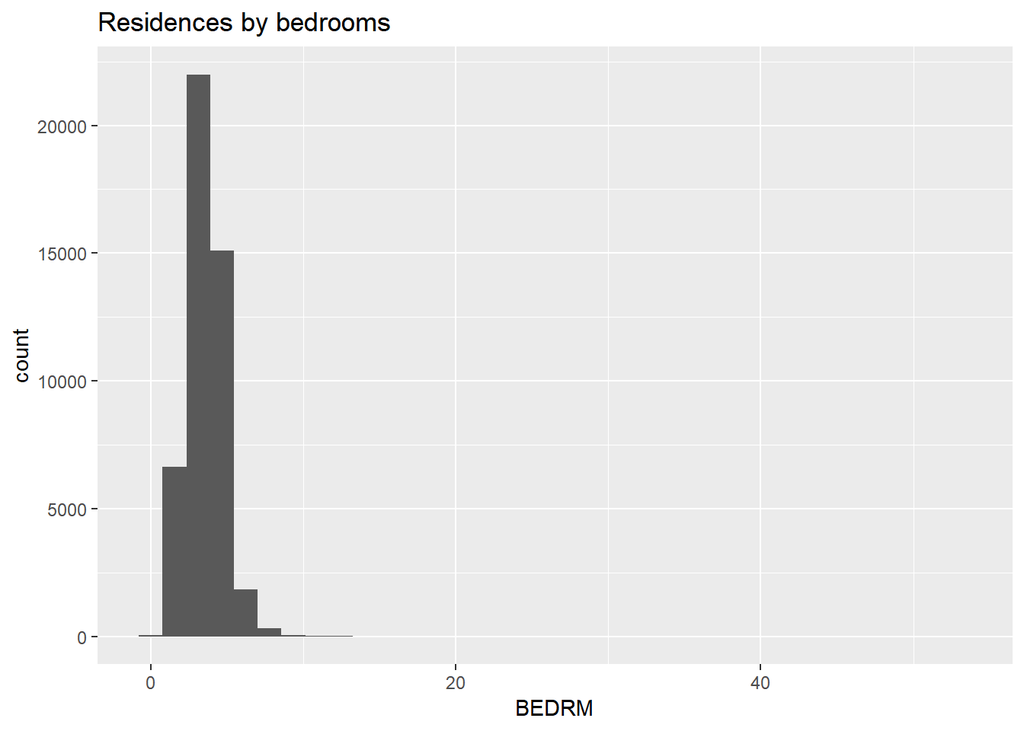

```r
res_data_modelling %>%
  select(BEDRM) %>%
  ggplot(data = ., aes(x = BEDRM)) +
  geom_histogram(bins=35) +
  labs(title = 'Residences by bedrooms')
```

```r
BEDROOMS_outlier_rows <- which(res_data_modelling$BEDRM == 0 |
        res_data_modelling$BEDRM >12 )
```

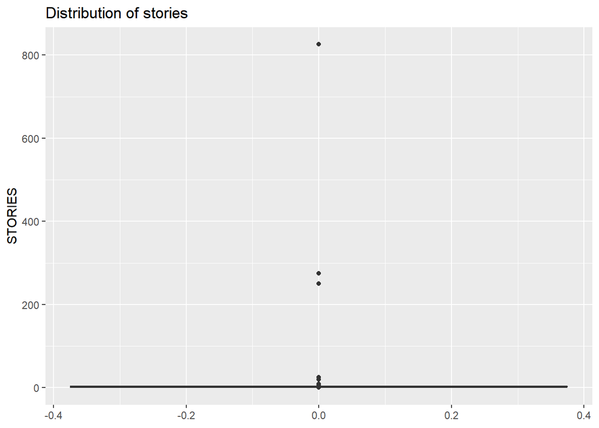

```r
res_data_modelling %>%
  select(STORIES) %>%
  ggplot(data = ., aes(y = STORIES)) +
  geom_boxplot() +
  labs(title = 'Distribution of stories')
```

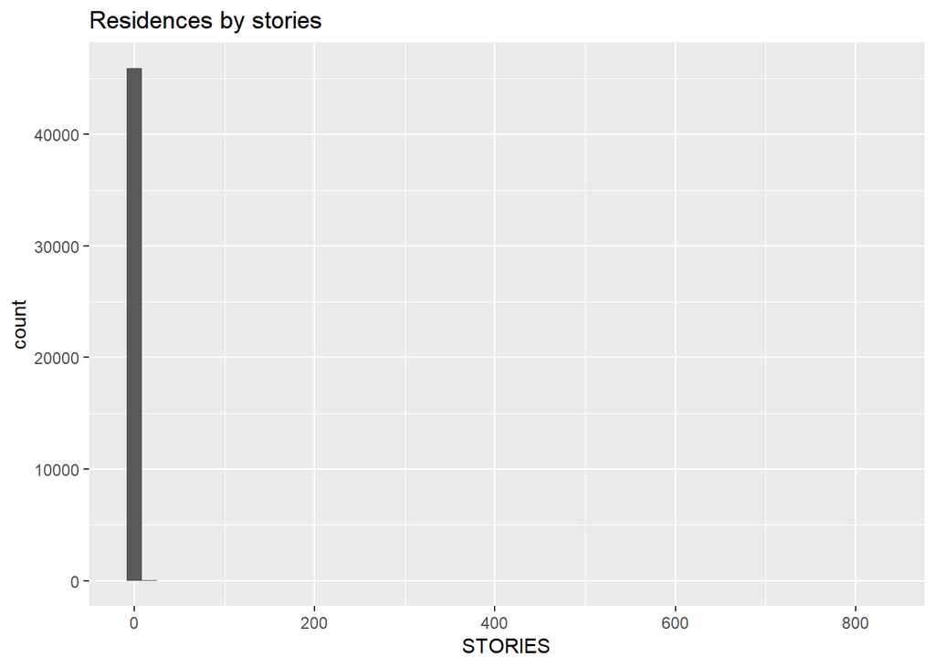

```r
res_data_modelling %>%
  select(STORIES) %>%
  ggplot(data = ., aes(x = STORIES)) +
  geom_histogram(bins=50) +
  labs(title = 'Residences by stories')
```

```r
STORIES_outlier_rows <- which(res_data_modelling$STORIES > 10 )
```

Clearly any buildings with more than 10 stories is outlier.

```r
outlier_rows <- STORIES_outlier_rows %>%
  union(BEDROOMS_outlier_rows) %>%
  union(ROOMS_outlier_rows) %>%
  union(PRICE_outlier_rows) %>%
  sort()
res_data_modelling <- res_data_modelling[-outlier_rows,]
```

```r
trainIndex = createDataPartition(res_data_modelling$PRICE, p=0.8, list=FALSE)
train_residence_df <- res_data_modelling[trainIndex, ]
test_residence_df <-  res_data_modelling[-trainIndex, ]
train_obj <- train_residence_df %>% select(OBJECTID)
train_residence_df <- train_residence_df %>% select(-OBJECTID)
test_obj <- test_residence_df %>% select(OBJECTID)
test_residence_df <- test_residence_df %>% select(-OBJECTID)
```

### 0.5.2 scale data.

```r
set.seed(12309)
scaled_data_model <- preProcess(train_residence_df %>%
                                  select(-PRICE, -PRICE_LOG),
                                method = 'scale')
train_residence_df_scaled <- predict(scaled_data_model,
                                     newdata = train_residence_df %>%
                                       select(-PRICE))
test_residence_df_scaled <- predict(scaled_data_model,
                                    newdata = test_residence_df %>%
                                       select(-PRICE))
```